# STAT 240: ggplot2

##### EXERCISE: Multiples of One Variable Plots

- This exercise will introduce the idea of comparing the distribution of a single variable across groups by replicating the plot within each group. To do this, it will introduce the `group`, `color`, `fill` variable aesthetics as powerful subgroup plotting tools.
- For this exercise, we’ll need to create a `century` column, which is either “19” for the 1800’s, “20” for the 1900’s, or “21” for the 2000’s. (We’ll also continue to use this variable through the rest of the file.)

```r
# You'll learn more about this code next week!
mendota = mendota %>%
  mutate(century = as.character(floor(year1/100)+1),
         century = case_when(
           century == "19" ~ "19th",
           century == "20" ~ "20th",
           century == "21" ~ "21st"
         ))
```

- Run this code to generate three basic single-variable plots for `duration`.

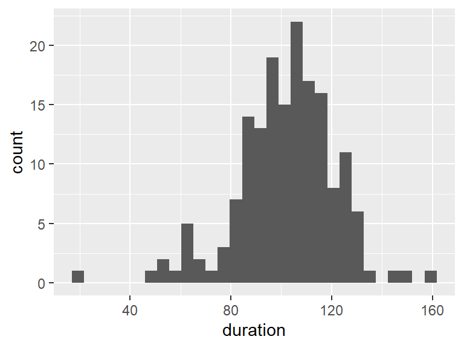

```r
ggplot(mendota, aes(x = duration)) +
  geom_histogram()
```

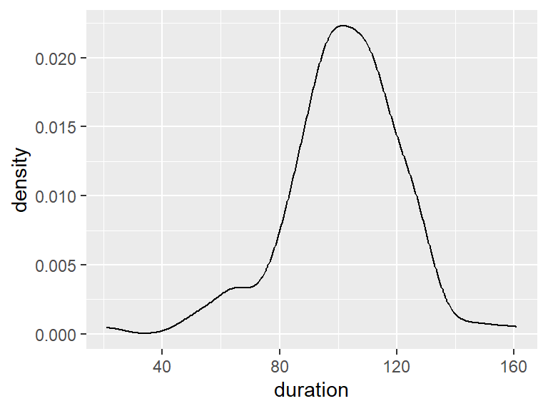

```r
ggplot(mendota, aes(x= duration)) +
  geom_density()
```

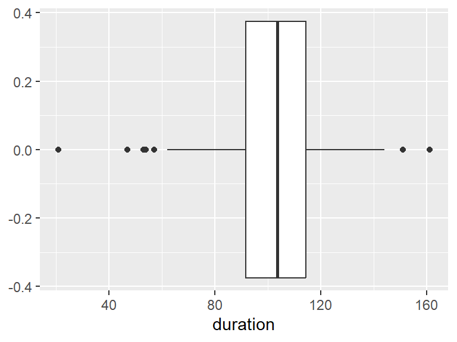

```r
ggplot(mendota, aes(x = duration)) +
  geom_boxplot()
```

- Now, to each of these plots, add the variable aesthetic `fill = century`. Observe the similarities and differences in the way the three plots change.
  - What do you think would have happened if we had instead specified `color = century` and not `fill`? Try it out!
- Make a change to the density plot (with `fill = century` applied) to make it easier to see all three plots, even when they are overlapping. (*Hint: consider the previous exercise!*)

> Technical takeaway: Using a categorical variable for color or fill will generate three subplots on the same panel.

> Philosophical takeaway: There are pros and cons to each of these three subgrouped single-variable plots. Histograms show you the proportion of each subgroup within each interval, density plots keep the scale constant across the groups even if they are not equal size, and boxplots make it easy to compare quartiles and medians. It is up to you as the data scientist to determine what your viewer cares about.

## Bar Graphs

> There are two functions to create bar graphs; `geom_bar` is a shortcut to plot occurrences of a single categorical variable, and `geom_col` is a more general two-variable bar graph function.

### geom_bar

> `geom_bar` takes in a single categorical variable and plots the number of occurrences of each category.
- Notice this definition is very similar to `geom_histogram`. The difference is that `geom_histogram` takes a *numeric* variable and counts the number of occurrences in custom bins, while `geom_bar` takes a *categorical* variable and counts the number of occurrences of each already existing category.

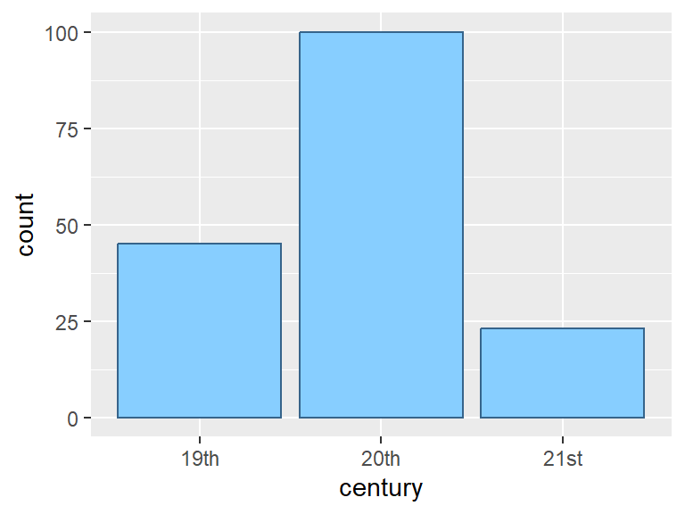

```r
ggplot(mendota, aes(century)) +
  geom_bar(
    color = "steelblue4",
    fill = "skyblue1"
  )
```

- Interpretation of this plot: Our dataframe has 45 observations from the 19th century, 100 observations from the 20th century, and 23 observations from the 21st century.
  - Those numbers were not directly in our dataframe, it counted them for us.
- Unlike `geom_histogram`, `geom_bar` puts spaces between its columns to indicate that these are distinct categories, NOT a continuous numeric variable being split up into bins.
  - By default, the categories are ordered alphabetically, which happened to be what we wanted here.

### geom_col

> `geom_col` takes in one categorical variable and one numeric variable, and creates one bar for each row in the dataframe, with the heights specified by that numeric variable.
- With `geom_col`, you provide the heights of the bars. This can be both a strength and a weakness.
  - `geom_col` allows you to plot more than just number of occurrences; like we’ll see below, it can be helpful to put something other than a count on the other axis.
  - If you do want to plot number of occurrences, `geom_col` requires you to do the calculation of the heights, while `geom_bar` does not.
- The below code takes our 168 winters in `mendota` and reduces it to three rows, one for each century that we want to plot. You’ll learn more about this code next week.

```r
mendota_summarized = mendota %>%
  group_by(century) %>%
  summarize(numYears = n(), avgDuration = mean(duration))

mendota_summarized
```

```
## # A tibble: 3 × 3
##   century numYears avgDuration
##   <chr>      <int>       <dbl>
## 1 19th          45       114.
## 2 20th         100       100.
## 3 21st          23        85.0
```

- Notice how this data is different from the data we passed into `geom_bar`. The data above, for `geom_col`, has one row per visual bar. The data below, for `geom_bar`, has way more rows in the dataset than we will eventually have bars on the graph.

```r
mendota %>%
  select(winter, century) %>% head()
```

```
## # A tibble: 6 × 2
##   winter  century
##   <chr>   <chr>
## 1 1855-56 19th
## 2 1856-57 19th
## 3 1857-58 19th
## 4 1858-59 19th
## 5 1859-60 19th
## 6 1860-61 19th
```

- Using the `mendota_summarized` dataframe above, we can specify the “custom” heights of bars to be the number of years in each century, which we calculated. By doing this, we have recreated exactly what `geom_bar`.

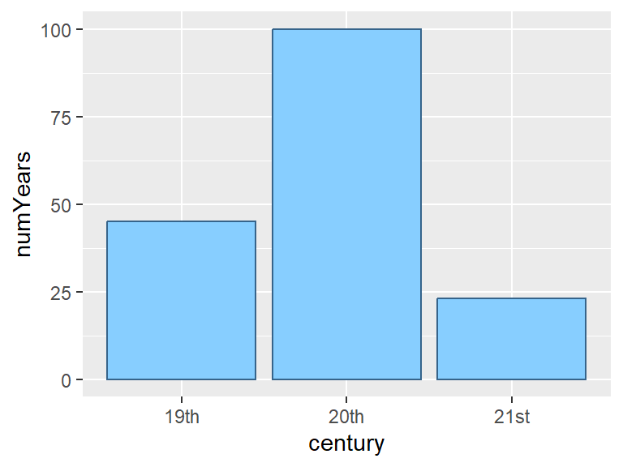

```r
ggplot(mendota_summarized, aes(century, numYears)) +
  geom_col(
    color = "steelblue4",
    fill = "skyblue1"
  )
```

- However, `geom_col`’s advantage is to be able to make bar graphs of more than just counts. For example, we calculated the average `duration` within each century above, and can set those to be the heights of the bars.

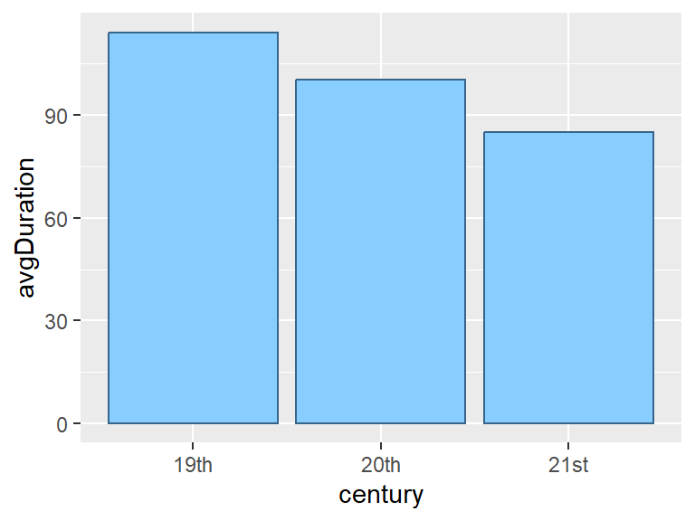

```r
ggplot(mendota_summarized, aes(century, avgDuration)) +
  geom_col(
    color = "steelblue4",
    fill = "skyblue1"
  )
```

##### EXERCISE: More Than One Right Answer

- Earlier in this lecture, we reflected on the question: “How has the duration of closure of Lake Mendota each winter changed over time?’
- The above bar graph, at the end of the `geom_col` section, is one possible way to answer this question. We also used a scatter plot with `geom_smooth()` earlier, which I will remind you of here:

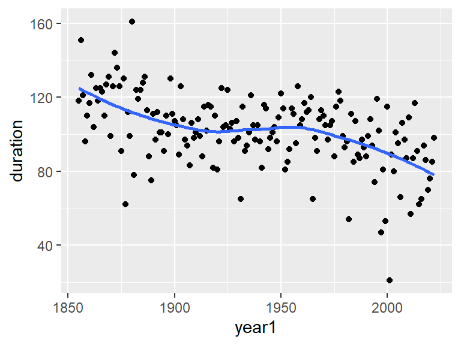

```r
ggplot(mendota, aes(year1, duration)) +
  geom_point() +
  geom_smooth(se = F)
```

- **Reflect on at least one thing the scatter plot illustrates better than the bar graph, and one thing the bar graph shows better than the scatter plot**.

> Philosophical takeaway: Two very different graphs can answer the same question, and it is subjective which one is the “better” answer.

## Annotating With Lines

- A common graphical task is to annotate a horizontal or vertical line at some useful or interesting point on a graph to draw attention to it.
- `geom_vline` creates a vertical line, and one required aesthetic: `xintercept`, which controls the horizontal position of the line.
- `geom_hline` creates a horizontal line, and one required aesthetic: `yintercept`, which controls the vertical position of the line.
- Both additionally accept useful constant aesthetics like `size`, `color`, and `linetype` (“solid” by default, “dashed”, “dotted”, and more, see `?linetype`).
- Here’s an example of annotating where the mean is on top of a histogram; you have to calculate the value yourself.

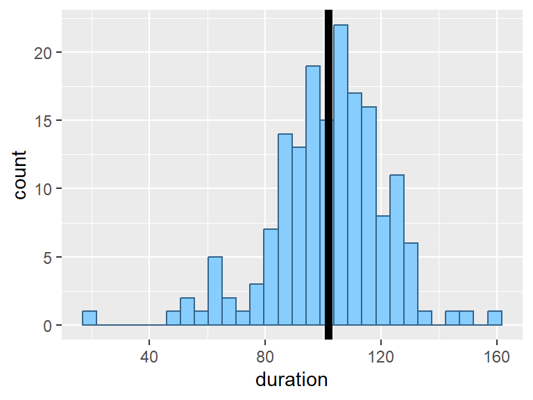

```r
meanDuration = mean(mendota$duration)

ggplot(mendota, aes(duration)) +
  geom_histogram(
    color = "steelblue4",
    fill = "skyblue1"
  ) +
  geom_vline(xintercept = meanDuration,
             size = 2)
```

```r
# Note: even though xintercept = meanDuration technically has a variable in it, that variable just contains one single number. It is not a column in the dataframe mendota. Therefore, this is a constant aesthetic and does not require aes().

# A reminder: geom_vline() should come AFTER geom_histogram! What would happen if we put geom_vline() before the geom_histogram?
```

- You can also give a vector of values as the `xintercept`.

```r
usefulValues = meanDuration + c(-3, -2, -1, 1, 2, 3) * sd(mendota$duration)
# A vector with length six; these values are meaningful statistically, we'll learn why in the second half of the course
usefulValues
```

```
## [1]  43.18356  62.76126  82.33896 121.49437 141.07207 160.64977
```

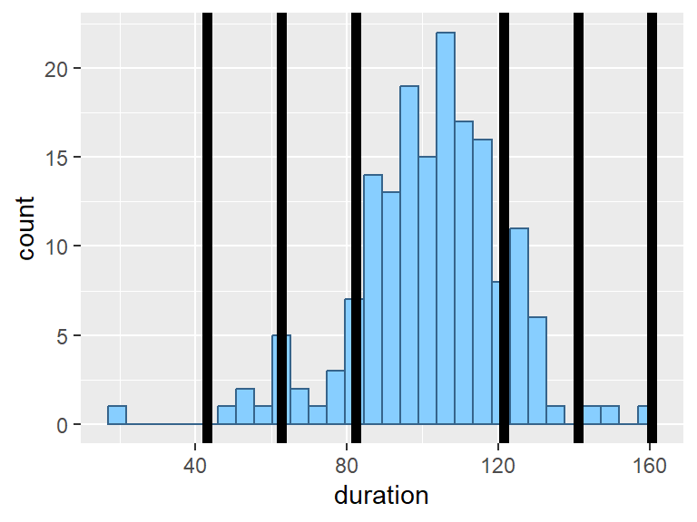

```r
ggplot(mendota, aes(duration)) +
  geom_histogram(
    color = "steelblue4",
    fill = "skyblue1"
  ) +
  geom_vline(xintercept = usefulValues,
             size = 2)
```

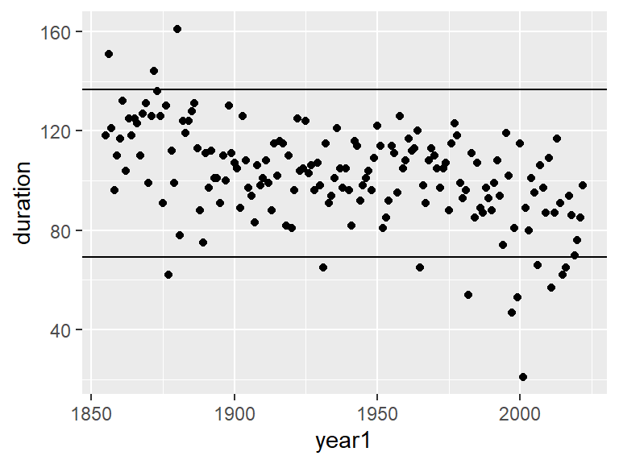

```r
iqr = IQR(mendota$duration)
firstQuartile = quantile(mendota$duration, 0.25)
thirdQuartile = quantile(mendota$duration, 0.75)

ggplot(mendota, aes(x = year1, y = duration)) +
  geom_point() +
  geom_hline(
    yintercept = c(firstQuartile - iqr, thirdQuartile + iqr)
    )
```

# Deeper Customization

- We have mentioned many times and shown a few examples of `ggplot2` allowing very granular customization of plots; this section will take you through a few of the many ways you can customize `ggplot`s.
- While we will continue to add these customizations with `+`, the addition of these functions primarily serves to edit previously created layers.

## Scales

> Editing graphical properties of the axes is done with the family of `scale_x_*` and `scale_y_*` commands.
- The asterisk specifies the type of variable on that axis. For example, `continuous` for variables like `duration` (which can take on any numeric value in a given range), or `discrete` for variables like `century` (which only take on one of a finite set of categories).
- We will most commonly use:
  - `scale_x_continuous()`
  - `scale_y_continuous()`
  - `scale_x_discrete()`
  - `scale_y_discrete()`
- Just like `geom`s, there are too many examples of `scale` functions to go over in one lecture; we will see many over the course of the class.
- Helpful arguments you can pass into `scale` functions include:
  - `breaks`, a vector of locations to draw grid lines and labels at.
  - `labels`, a vector of names to use as the label of each break-point.
  - `limits`, a vector of two numbers specifying the left and right limit of how wide/tall you want the plot to be
  - `trans`, standing for “transformation”, which allows you to do some numeric transformation of the axis; including “reverse”, “sqrt”, and “log”.

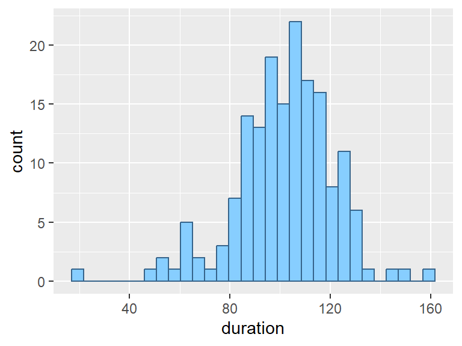

```r
# Notice ggplot's default x-axis choices
ggplot(mendota, aes(duration)) +
  geom_histogram(
    color = "steelblue4",
    fill = "skyblue1"
  )
```

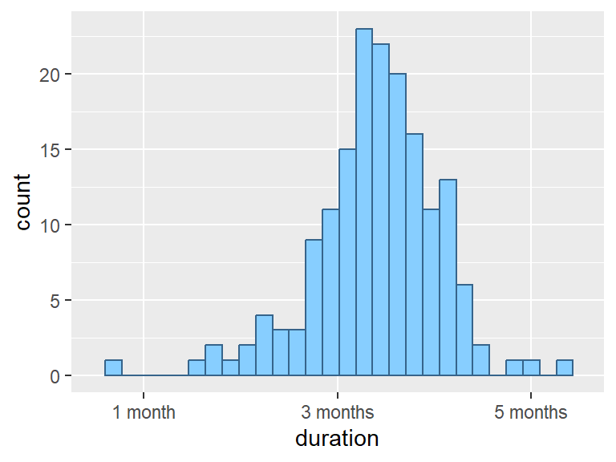

```r
ggplot(mendota, aes(duration)) +
  geom_histogram(
    color = "steelblue4",
    fill = "skyblue1"
  ) +
  scale_x_continuous(
    breaks = c(30, 90, 150),
    labels = c("1 month", "3 months", "5 months"),
    limits = c(15, 165),
    minor_breaks = NULL, # This specifies not to draw any vertical axis lines between the labeled points; not necessarily something you have to memorize, just an example of how far you can customize!
  )
```

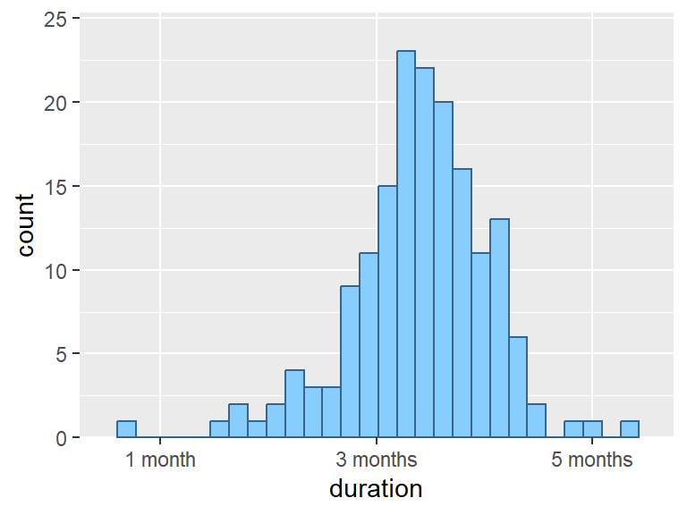

```r
ggplot(mendota, aes(duration)) +
  geom_histogram(
    color = "steelblue4",
    fill = "skyblue1"
  ) +
  scale_x_continuous(
    breaks = c(30, 90, 150),
    labels = c("1 month", "3 months", "5 months"),
    limits = c(15, 165),
    minor_breaks = NULL
  ) +
  # Can you figure out what this addition is doing to the y-axis?
  scale_y_continuous(
    expand = expansion(mult = c(0,0.1))
  )
```

### Color Scales

> When color is mapped to a variable aesthetic, you can use the `viridis` color scales for accessible preset options, or use the `manual` functions to set a custom color scale.
- Recall the following plot from a previous exercise:

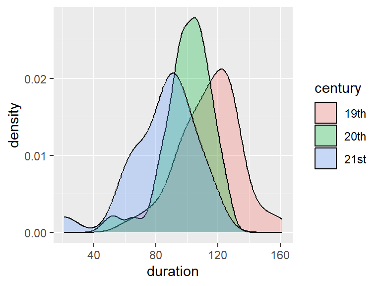

```r
ggplot(mendota, aes(x= duration, fill = century)) +
  geom_density(alpha = 0.3)
```

- `ggplot`’s default color schemes can be hard to distinguish for people with common forms of color blindness.
  - The “viridis” color scales are designed to remedy this.
  - Depending on whether your variable is continuous (`c`) or discrete (`d`), and whether you used `color` or `fill` as the aesthetic, you can use one of the following four commands:
    - `scale_color_viridis_c()`
    - `scale_color_viridis_d()`
    - `scale_fill_viridis_c()`
    - `scale_fill_viridis_d()`
- For example, in the plot above, we use `fill` as the aesthetic controlling color, with `century` a discrete/categorical variable, so we use `scale_fill_viridis_d()`.
- See two examples below; there are many options within viridis, see [here (scroll a little down)](https://cran.r-project.org/web/packages/viridis/vignettes/intro-to-viridis.html) for more details.

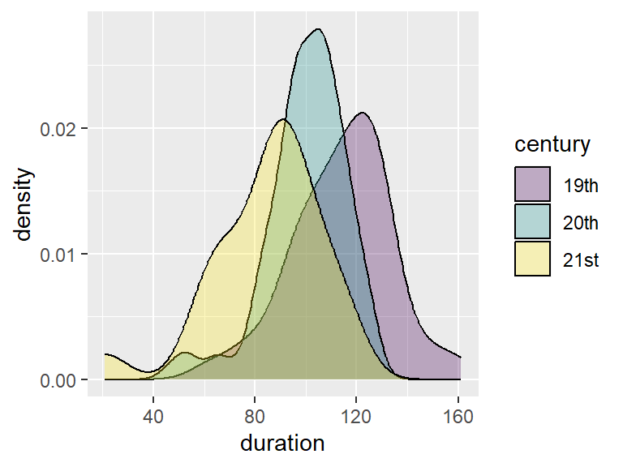

```r
ggplot(mendota, aes(x= duration, fill = century)) +
  geom_density(alpha = 0.3) +
  scale_fill_viridis_d()
```

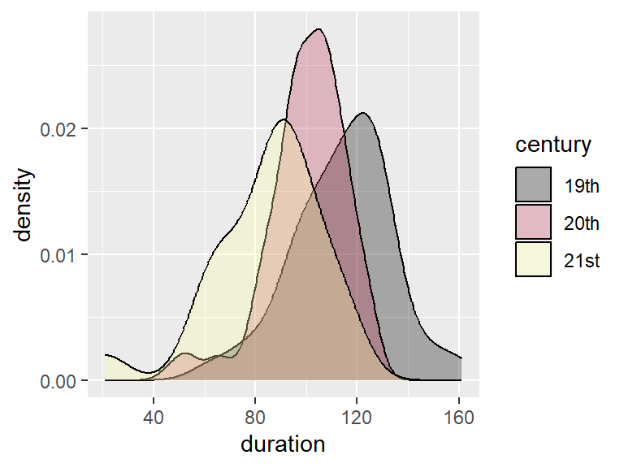

```r
ggplot(mendota, aes(x= duration, fill = century)) +
  geom_density(alpha = 0.3) +
  scale_fill_viridis_d(option = "inferno")
```

- Alternatively, you might have a custom color scheme in mind. `scale_color_manual` and `scale_fill_manual` exist to help you; the `values` argument accept a vector of pairs, where you map values of the categorical variable to colors.

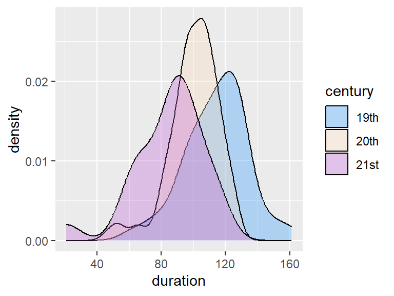

```r
ggplot(mendota, aes(x= duration, fill = century)) +
  geom_density(alpha = 0.3) +
  scale_fill_manual(
    values = c("19th" = "dodgerblue", "20th" = "peachpuff", "21st" = "mediumorchid")
    )
```

## Plot Labels

> All plot labeling can be done with the `labs()` (standing for labels) function.
- `labs()` can be used to add a title, subtitle, and caption; see placement examples below.
- It can also be used to adjust the axes labels and legend titles.
  - The legend title is controlled in `labs()` by whatever aesthetic you used to create the legend.
  - For example, in this plot we create the legend with `fill = century`, so the legend title is adjusted with `fill = "legend title"`.

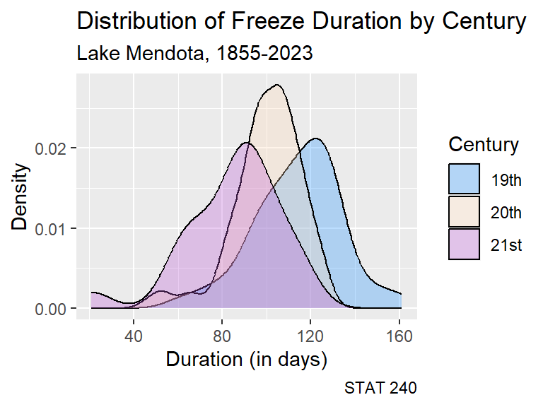

```r
densityPlot = ggplot(mendota, aes(x= duration, fill = century)) +
  geom_density(alpha = 0.3) +
  scale_fill_manual(
    values = c("19th" = "dodgerblue", "20th" = "peachpuff", "21st" = "mediumorchid")
    ) +
  labs(
    title = "Distribution of Freeze Duration by Century",
    subtitle = "Lake Mendota, 1855-2023",
    caption = "STAT 240",

    x = "Duration (in days)",
    y = "Density",
    fill = "Century" # If you created your legend with the size aesthetic, this would be size = "legend title", or color would be color = "legend title", et cetera
  )

densityPlot
```

## Themes

> `ggplot2` comes with many built-in themes to improve the appearance of the graph over the default theme, such as `theme_minimal()`.

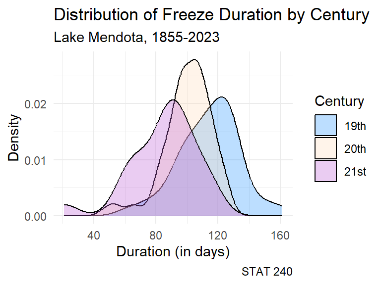

```r
densityPlot +
  theme_minimal()
```

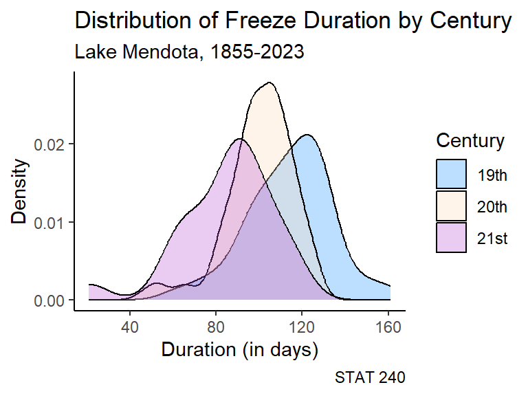

```r
densityPlot +
  theme_classic()
```

- The [tidyverse list of complete themes](https://ggplot2.tidyverse.org/reference/ggtheme.html) are part of the tidyverse online reference.
  - You can also type `?theme_gray` or any other theme in your console.

##### EXERCISE: Dissect a Real Visualization

- Consider the following graph which appeared in a recent [ESPN article](https://www.espn.com/soccer/insider/insider/story/_/id/39241757/explaining-arsenal-losses-investigation-stats-analysis).

[figure not shown]

If you want this image to appear when you knit the file, make sure you have “ESPNExample.png” downloaded right next to this Rmd file in COURSE/lecture/week02-ggplot.

- Consider this partial dataframe below:

```r
teams = c("Wolves", "Aston Villa", "Liverpool", "Tottenham", "Man City")
ESPN = tibble(team = factor(teams, levels = teams),
       points = c(2.0, 2.0, 2.2, 2.4, 2.5))

ESPN
```

```
## # A tibble: 5 × 2
##   team        points
##   <fct>        <dbl>
## 1 Wolves         2
## 2 Aston Villa    2
## 3 Liverpool      2.2
## 4 Tottenham      2.4
## 5 Man City       2.5
```

- Using the `ESPN` dataframe, write code to plot the basic form of this graph; i.e. a call to `ggplot` and a `geom`.
  - Make sure team is on the vertical axis, not the horizontal one!

```r
# Write basic code here
```

- Identify two customized improvements that the published ESPN plot has which the basic plot above does not. Identify the functions you could use to mimic those improvements. (You do not need to go into detail of the arguments of the function, just the name of the function.)

## Sidenote: Shortcut Functions

- I have shown the “general” form of all the customization functions above. Many of the more common tasks have shortcut functions; they are useful if you only need to make one change.
- I prefer the general form because they can accomplish everything these shortcuts can do and more, and you have less functions to memorize.
- Examples of shortcut functions include:
  - `xlim(c(a, b))` is the same as `scale_x_continuous(limits = c(a, b))`, and similarly for `y`.
  - `scale_x_reverse()` is the same as `scale_x_continuous(trans = "reverse")`, and similarly for `y`.
  - `ggtitle("my title")` is the same as `labs(title = "my title")`.
  - `xlab("x axis title")` is the same as `labs(x = "x axis title")`, and similarly for `y`.

# Faceting

## facet_wrap

> Faceting with `facet_wrap` is a way to replicate a single plot within each subgroup defined by a categorical variable.
- When replicating a single plot, we reviewed in a previous exercise how to use `color` or `fill` to overlay separate marks for each subgroup on the same panel, as below.

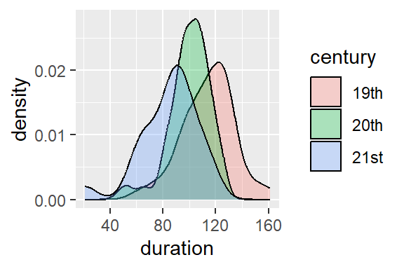

```r
ggplot(mendota, aes(x= duration, fill = century)) +
  geom_density(alpha = 0.3)
```

- However, we may also just want to split each onto its own plot. This is called **faceting**.
- The function `facet_wrap` requires one argument, `facets`; the variable by which you want to split the plot. One panel will be generated for each category of that variable.
  - `facet_wrap` requires you to surround this variable with the `vars()` function, like in the example below.
  - Unfortunately, this is just something that you have to memorize. If you do not use `vars()`, it will say `object 'century' not found`, or whatever variable you used.

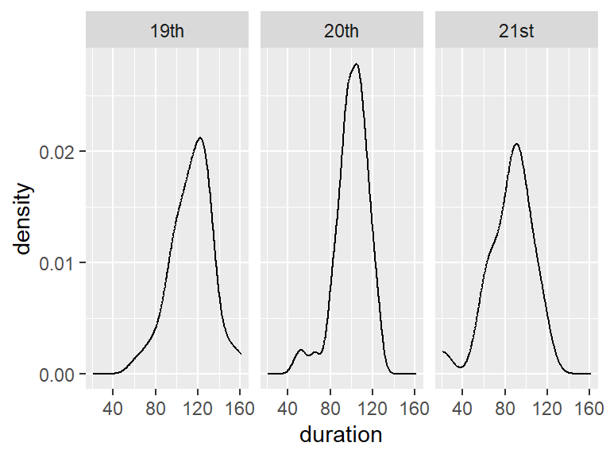

```r
ggplot(mendota, aes(x = duration)) +
  geom_density() +
  facet_wrap(facets = vars(century))
```

## facet_grid

- You can also facet by *two* variables with `facet_grid`, which requires you to specify the `rows` variable and `cols` variable with `vars()`.
- This is most useful when you have two variables for which every combination exists in the data. For example, faceting by `decade` and `century` doesn’t help much, because each decade only appears in one century.

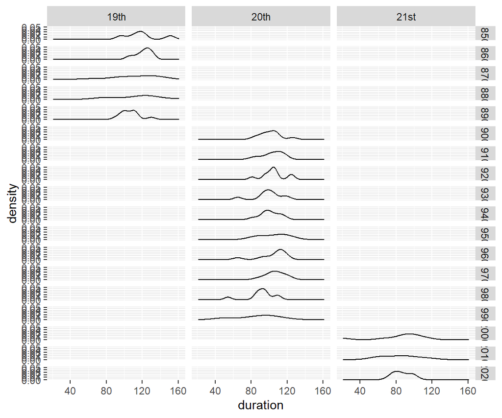

```r
ggplot(mendota, aes(x = duration)) +
  geom_density() +
  facet_grid(rows = vars(decade), cols = vars(century))
```

- Perhaps a more effective choice to communicate the same information as above would be to facet by `decade` and fill by `century.`

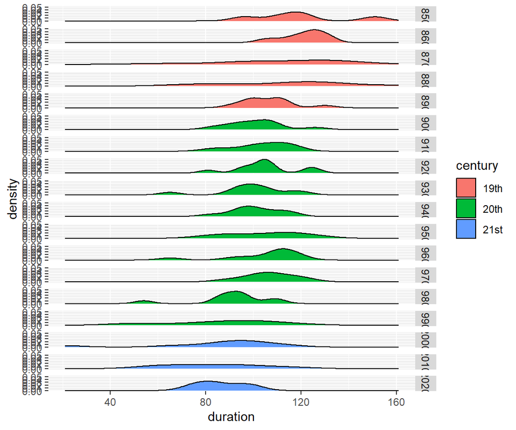

```r
ggplot(mendota, aes(x = duration, fill = century)) +
  geom_density() +
  facet_grid(rows = vars(decade))
```

- Consider a column `leap_year` which identifies if `year1` for each winter was a leap year.
  - Code to create this column is included in the .Rmd but suppressed in the knitted file.

```
## # A tibble: 6 × 2
##   year1 leap_year
##   <dbl> <lgl>
## 1  1855 FALSE
## 2  1856 TRUE
## 3  1857 FALSE
## 4  1858 FALSE
## 5  1859 FALSE
## 6  1860 TRUE
```

- Leap years have occurred in every century; so it makes sense to facet by both `century` and `leap_year`.

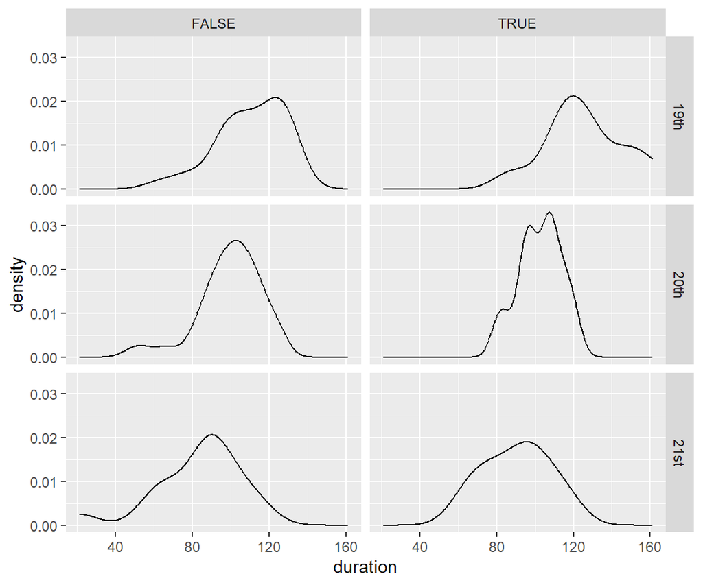

```r
ggplot(mendota, aes(x = duration)) +
  geom_density() +
  facet_grid(rows = vars(century), cols = vars(leap_year))
```

##### EXERCISE: Interpreting a Faceted Plot

- Consider the above graph, at the end of the `facet_grid` section
- Choose from the given options to correctly interpret the above plot:
- The top left panel shows the distribution of `duration` among **(leap years/non-leap years)** in the **(19th/20th/21st)** century.
- The bottom right panel shows the distribution of `duration` among **(leap years/non-leap years)** in the **(19th/20th/21st)** century.
- We don’t expect there to be a difference in average duration between non-leap years and leap years. This is illustrated by the fact that each **(row of panels/column of panels)** has roughly the same center across each of its panels.
- We do expect there to be a difference in average duration across centuries. This is illustrated by the fact that each **(row of panels/column of panels)** has different centers across each of its panels.

> Technical takeaway: The subgroup represented in an individual faceted panel can be defined by one OR two variables; the faceting commands do a decent but not perfect job of labeling them.

> Philosophical takeaway: Faceting is another valuable tool for showing two-variable relationships. It is especially helpful when we have too many subgroups to overlay on a single panel.
- Philosophical takeaway continued: Notice how difficult it is to encode `leap_year` AND `century` with just aesthetics.

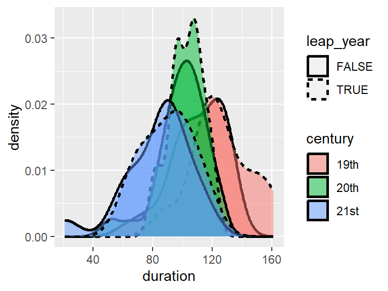

```r
ggplot(mendota, aes(x = duration, fill = century, linetype = leap_year)) +
  geom_density(alpha = 0.5, size = 1)
```